# Trabajo Final

Buitrago_RosalesMarkaida_Vinchery

2024-11-27

# Configuración

Configuración y ejecución de análisis estadísticos replicando el artículo *Climate Actions by Climate and Non-Climate Researchers* (Dablander, Sachisthal, & Haslbeck, 2024). Este análisis se lleva a cabo en el marco de la asignatura Analítica de Datos Aplicada a Estudios sobre Desarrollo del Centro Interdisciplinario de Desarrollo de la Universidad de Los Andes, como trabajo final del curso.

Enlace de descarga y cita del artículo académico utilizado: Dablander, F., Sachisthal, M. S. M., & Haslbeck, J. M. B. (2024). Climate actions by climate and non-climate researchers. npj Climate Action, 3(1), 105. https://doi.org/10.1038/s44168-024-00187-1

Enlace de descarga de los archivos utilizados en el script: https://github.com/JulianaRosalesMarkaida/ClimateActionAnalysis/tree/main

```r
rm(list = ls())
```

```r
# Configurar opciones globales para el código R
knitr::opts_chunk$set(
  echo = TRUE, warning = FALSE, message = FALSE, eval = TRUE, cache = FALSE,
  fig.align = 'center', fig.width = 10, fig.height = 12, dpi = 300,
  out.width='100%', out.height='100%'
)
```

```r
# Cargar las librerías necesarias para el análisis y visualización
library(brms)
library(caret)
library(knitr)
library(dplyr)
library(scales)
library(ggplot2)
library(forcats)
library(corrplot)
library(latex2exp)
library(BayesFactor)
library(tidyverse)
library(qualtRics)
library(kableExtra)
library(RColorBrewer)
```

```r
library(RCurl)

# Leer el contenido del archivo R desde GitHub (versión Raw)
url <- "https://raw.githubusercontent.com/JulianaRosalesMarkaida/ClimateActionAnalysis/main/helpers.R"
file_content <- getURL(url)

# Ejecutar el código del archivo
eval(parse(text = file_content))
```

Luego de ejecutar el código anterior, es posible visualizar lo siguiente en el *Environment*:

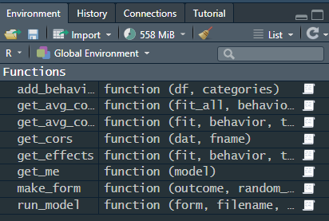

Imagen helpersR

# Preparación de los datos

Carga de los datos y creación de variables y categorizaciones que serán útiles para los análisis posteriores.

Ruta para descargar el archivo DataS3_Final.RDS de github: https://github.com/JulianaRosalesMarkaida/ClimateActionAnalysis/raw/refs/heads/main/data/DataS3_Final.RDS

```r
# Cargar el archivo DataS3_Final.RDS desde la ruta local
dat_final <- readRDS('C:/Users/julia/Desktop/UNIANDES/ANDATOS/Entrega Final/Paper/data/DataS3_Final.RDS') %>%
  # Aplicar transformaciones y crear nuevas variables
  mutate(
    engaged_protest = as.numeric(BehLegal == 2),  # Identificar si el investigador participó en protestas (comportamiento cívico)
    engaged_advocacy = as.numeric(Beh_EngPub == 2),  # Identificar si el investigador participó en actividades de defensa pública
    research_fact = factor(  # Crear una variable categórica para el nivel de implicación en el cambio climático
      Research_std,
      labels = c("Not at all", "Very little", "A moderate amount", "Quite a bit", "A great deal")
    )
  )

# Cargar el archivo DataS1_Anonymized.RDS desde la ruta local
dat_num <- readRDS('C:/Users/julia/Desktop/UNIANDES/ANDATOS/Entrega Final/Paper/data/DataS1_Anonymized.RDS') %>%
  # Crear variables categóricas relacionadas con el campo de investigación y el tipo de posición académica
  mutate(
    # Categorizar los campos de investigación
    humanities = as.numeric(Field == 1 | open_field == "Humanities (e.g., History, Languages, Law)"),
    social_science = as.numeric(Field == 2 | open_field == "Social and behavioural sciences (e.g., Economics, Sociology, Psychology)"),
    formal_science = as.numeric(Field == 4 | open_field == "Formal sciences (e.g., Computer science, Logic, Mathematics)"),
    applied_science = as.numeric(Field == 5 | open_field == "Professions and applied sciences (e.g., Agriculture, Engineering)"),
    medical_science = as.numeric(open_field == "Medical sciences"),
    other_science = as.numeric(open_field == "Other, please specify:"),

    # Crear una columna 'fieldname' con nombres acordes para los campos de investigación
    fieldname = case_when(
      humanities == 1 ~ 'Humanities',
      social_science == 1 ~ 'Social and behavioural sciences',
      formal_science == 1 ~ 'Formal sciences',
      applied_science == 1 ~ 'Professions and applied sciences',
      medical_science == 1 ~ 'Medical sciences',
      other_science == 1 ~ 'Other',
      TRUE ~ 'Natural sciences'
    ),

    # Categorizar la posición académica
    position_name = case_when(
      Position == 1 ~ 'PhD candidate',
      Position == 2 ~ 'Postdoc',
      Position == 3 ~ 'Assisstant professor',
      Position == 4 ~ 'Associate professor',
      Position == 5 ~ 'Full professor',
      TRUE ~ 'Other'
    ),

    # Crear variables binarias para las acciones relacionadas con el cambio climático
    reduced_car = as.numeric(Beh_incNotApp_1 == 2),
    electric_vehicle = as.numeric(Beh_incNotApp_2 == 2),
    energy_home = as.numeric(Beh_incNotApp_3 == 2),
    fewer_children = as.numeric(Beh_incNotApp_4 == 2),
    talk_climate = as.numeric(Beh_incNotApp_5 == 2),
    donate_money = as.numeric(Beh_incNotApp_6 == 2),
    veggie_diet = as.numeric(Beh_incNotApp_7 == 2),
    reduced_flying = as.numeric(Beh_incNotApp_8 == 2),

    signed_petitions = as.numeric(Beh_others_1 == 2),
    advocated_change = as.numeric(Beh_others_2 == 2),
    engaged_policymakers = as.numeric(Beh_others_3 == 2),
    wrote_letters = as.numeric(Beh_others_4 == 2),
    engaged_disobedience = as.numeric(Beh_others_7 == 2),
    engaged_protest = as.numeric(BehLegal == 2),
    engaged_advocacy = as.numeric(Beh_EngPub == 2)
  )

# Asignar niveles a las categorías de la variable 'position' para crear una jerarquía
dat_final$position <- factor(
  dat_num$position_name,
  levels = c(
    'Full professor', 'Associate professor', 'Assisstant professor',
    'Postdoc', 'PhD candidate', 'Other'
  )
)

# Asignar la variable 'fieldname' desde 'dat_num' y crear un factor ordenado con los campos de investigación
dat_final$fieldname <- dat_num$fieldname
dat_final$field <- factor(
  dat_num$fieldname,
  levels = c(
    'Natural sciences', 'Social and behavioural sciences', 'Medical sciences',
    'Formal sciences', 'Humanities', 'Professions and applied sciences', 'Other'
  )
)

# Agregar información sobre país y continente, asignando valores por defecto cuando falte la información
dat_final$country <- ifelse(is.na(dat_num$Country), 'not specified', dat_num$Country)
dat_final$continent <- ifelse(is.na(dat_num$Continent), 'not specified', dat_num$Continent)

# Crear un subconjunto de datos solo con los investigadores más implicados en el cambio climático
dat_climate <- dat_final %>%
  mutate(
    climate_researcher = as.numeric(research_fact == 'A great deal')
  ) %>%
  filter(research_fact %in% c('Not at all', 'A great deal'))

# Crear un listado de los comportamientos relacionados con el cambio climático, diferenciando entre acciones cívicas y cambios de estilo de vida
behaviors <- list(
  # Civic behaviors (comportamientos cívicos)
  'talk_climate' = 'Talked about climate with others',
  'donate_money' = 'Donated to climate organizations',
  'signed_petitions' = 'Signed petitions',
  'advocated_change' = 'Advocated change within institution',
  'engaged_policymakers' = 'Engaged with politicians',
  'engaged_disobedience' = 'Engaged in civil disobedience',
  'engaged_protest' = 'Engaged in protest',
  'engaged_advocacy' = 'Engaged in advocacy',
  'wrote_letters' = 'Wrote letters to politicians',

  # Lifestyle behaviors (comportamientos relacionados con el estilo de vida)
  'reduced_flying' = 'Reduced flying',
  'reduced_car' = 'Reduced car usage',
  'electric_vehicle' = 'Switched to electric vehicle',
  'energy_home' = 'Switched to renewable energy at home',
  'veggie_diet' = 'Follows a mostly vegetarian or vegan diet',
  'fewer_children' = 'Decided to have fewer or no children'
)

# Mapear los nombres de los comportamientos para su posterior análisis
behavior_names_map <- unlist(behaviors)
behavior_map <- list(
  'Civic action' = names(behaviors[seq(9)]),  # Comportamientos cívicos
  'Lifestyle change' = names(behaviors[seq(10, 15)])  # Cambios de estilo de vida
)
```

# Análisis principal

Cálculo de las proporciones empíricas. Estos valores se emplearán en los análisis posteriores para comparar o modelar diferencias entre grupos.

```r
# Definir la función
add_behavior_categories <- function(df, behavior_map) {
  df$category <- NA
  for (category in names(behavior_map)) {
    behaviors_in_category <- behavior_map[[category]]
    df$category[df$behavior %in% behaviors_in_category] <- category
  }
  return(df)
}

# Código principal
df <- dat_final %>%
  group_by(Research_std) %>%
  summarize(across(all_of(names(behaviors)), mean)) %>%
  mutate(research = factor(
    Research_std, labels = c('Not at all', 'Very little', 'A moderate amount', 'Quite a bit', 'A great deal')
  )) %>%
  select(research, everything(), -Research_std) %>%
  pivot_longer(cols = -research, names_to = 'behavior', values_to = 'value') %>%

  # La función add_behavior_categories ya está definida y se puede utilizar
  add_behavior_categories(behavior_map) %>%

  mutate(behavior = unname(unlist(behaviors[behavior])))
```

```r
# Verificar las primeras filas del dataframe
head(df)
```

```
## # A tibble: 6 × 4
##   research   behavior                             value category
##   <fct>      <chr>                                <dbl> <chr>
## 1 Not at all Talked about climate with others    0.648  Civic action
## 2 Not at all Donated to climate organizations    0.272  Civic action
## 3 Not at all Signed petitions                    0.394  Civic action
## 4 Not at all Advocated change within institution 0.183  Civic action
## 5 Not at all Engaged with politicians            0.0452 Civic action
## 6 Not at all Engaged in civil disobedience       0.0425 Civic action
```

```r
# Verificar las primeras filas del dataframe con las categorías
df %>% select(behavior, category) %>% head()
```

```
## # A tibble: 6 × 2
##   behavior                            category
##   <chr>                               <chr>
## 1 Talked about climate with others    Civic action
## 2 Donated to climate organizations    Civic action
## 3 Signed petitions                    Civic action
## 4 Advocated change within institution Civic action
## 5 Engaged with politicians            Civic action
## 6 Engaged in civil disobedience       Civic action
```

```r
# Verificar cuántos comportamientos están en cada categoría
table(df$category)
```

```
##
##     Civic action Lifestyle change
##               45               30
```

## *Figure 1: Proportion of actions*

```r
library(doParallel)
library(marginaleffects)
registerDoParallel(cores = 10)

# Definir la lista de comportamientos a analizar
behavior_list <- names(behaviors)

# Especificar el modelo para el análisis
form <- make_form(
  'talk_climate', random_intercept = FALSE, random_slope = FALSE,
  binarize = TRUE, marginal = TRUE, worry = FALSE, informed = FALSE
)

filename <- '../models/climate_marginal_talk_climate.RDS'

# Ejecutar un modelo inicial para evitar recompilar los modelos luego
fit_initial_marginal <- run_model(
  form, filename, dat_climate, use_model = NULL,
  cores = 1, chains = 2, family = bernoulli, force = FALSE, iter = 4000, warmup = 500
)

# Ejecutar los modelos para cada comportamiento de manera paralelizada
fit_all_marginal <- foreach(i = seq(length(behaviors))) %dopar% {
  b <- names(behaviors)[i]

  filename <- paste0('../models/climate_marginal_', b, '.RDS')
  form <- make_form(
    b, random_intercept = FALSE, random_slope = FALSE, binarize = TRUE,
    marginal = TRUE, worry = FALSE, informed = FALSE
  )
  # Ajustar el modelo para cada comportamiento
  fit <- run_model(
    form, filename, dat_climate, use_model = fit_initial_marginal,
    cores = 1, chains = 2, family = bernoulli, force = FALSE, iter = 4000, warmup = 500
  )

  res <- list()
  res[[b]] <- fit
  res
}
# Obtener los efectos marginales para todos los modelos
df_marginal <- do.call('rbind', lapply(seq(15), function(i) {
  fit <- fit_all_marginal[[i]]
  behavior <- names(fit)
  # Calcular los efectos marginales para el comportamiento actual
  get_effects(fit[[1]], behavior, type = 'marginal')
}))
# Transformar los resultados para una mejor comprensión
df_marginal <- df_marginal %>%
  mutate(behavior = unname(unlist(behaviors[behavior])))
# Crear un dataframe con las probabilidades marginales
df_prob_marginal <- df %>%
  filter(research %in% c('Not at all', 'A great deal')) %>%
  mutate(climate_researcher = ifelse(research == 'A great deal', 1, 0)) %>%
  left_join(df_marginal, by = c('behavior', 'climate_researcher'))

# Ordenar según la mayor diferencia multiplicativa
df_prob_marginal_ord <- df_prob_marginal %>%
  group_by(behavior) %>%
  mutate(research_diff = max(estimate) / min(estimate)) %>%
  ungroup() %>%
  arrange(research_diff) %>%
  mutate(behavior = factor(behavior, levels = as.character(unique(behavior))))
```

```r
# Crear el gráfico y definir los colores
cols <- rev(c('#a50f15', '#08519c'))
p <- ggplot(df_prob_marginal_ord, aes(x = behavior, y = value, group = research, color = research)) +
  # Añadir las barras del gráfico para cada comportamiento
  geom_bar(
    stat = 'identity', position = position_dodge(width = 0.8),
    width = 0.70, aes(fill = research)
  ) +
  # Añadir puntos para las estimaciones de los valores
  geom_point(
    aes(x = behavior, y = estimate), position = position_dodge(width = 0.80),
    size = 2, show.legend = FALSE, color = 'black'
  ) +
  # Añadir barras de error para los intervalos de confianza
  geom_errorbar(
    aes(ymin = ci_lo, ymax = ci_hi), position = position_dodge(width = 0.80),
    width = 0.40, linewidth = 1, show.legend = FALSE, color = 'black'
  ) +
  # Añadir puntos para las estimaciones de los valores
  geom_point(
    aes(x = behavior, y = estimate), position = position_dodge(width = 0.80),
    size = 1, show.legend = FALSE
  ) +
  # Añadir barras de error para los intervalos de confianza
  geom_errorbar(
    aes(ymin = ci_lo, ymax = ci_hi), position = position_dodge(width = 0.80),
    width = 0.30, linewidth = 0.30,
    show.legend = FALSE
  ) +
  theme_minimal() +
  coord_flip() +
  xlab('') +
  ylab('Percent reported engaging') +
  scale_x_discrete(guide = guide_axis(angle = 0)) +
  scale_color_manual(values = cols) +
  scale_fill_manual(
    values = cols, labels = c('Non-climate researchers (n = 2,257)', 'Climate researchers (n = 1,565)')
  ) +
  scale_y_continuous(
    labels = label_percent(scale = 100), limits = c(0, 1), breaks = seq(0, 1, 0.10)
  ) +  # scale = 1 for proportions
  ggtitle('Climate actions by climate and non-climate researchers') +
  theme(
    legend.position = 'top',
    legend.title = element_blank(),
    panel.grid.minor = element_blank(),
    panel.grid.major.y = element_blank(),
    axis.title.x = element_text(size = 12),
    axis.title.y = element_text(size = 12),
    axis.text.x = element_text(size = 10),
    axis.text.y = element_text(size = 10),
    plot.title = element_text(hjust = .5, size = 14),
    strip.text.x = element_text(size = 9, face = 'bold')
  ) + guides(fill = guide_legend(reverse = TRUE), color = "none")
# Mostrar el gráfico y guardarlo en la carpeta "Figures", en una ubicación relativa
p
```

[figure not shown]

```r
ggsave('../figures/Figure1.pdf', p, width = 8, height = 10)
```

# Análisis complementarios

Reproducción de todas las figuras en el apéndice del artículo.

## *Figure S1: Adjusting for background and other variables*

Ajuste de los modelos utilizando variables de contexto. Adición de la variable sobre cómo una persona percibe estar informada sobre el cambio climático (la preocupación no mostró efectos adicionales). Ejecución de un *modelo bayesiano binomial* que modele el número de acciones cívicas y de estilo de vida en las que los investigadores participaron en general.

```r
# Registrar el uso de múltiples núcleos para paralelizar el proceso
registerDoParallel(cores = 10)

# Definir la fórmula para el modelo con variables de fondo (sin ajustar por el nivel de información)
form <- make_form(
  'talk_climate', random_intercept = FALSE, random_slope = FALSE,
  binarize = TRUE, marginal = FALSE, worry = FALSE, informed = FALSE
)

filename <- '../models/climate_background_talk_climate.RDS'

# Ejecutar un modelo inicial. Evita recompilar los modelos posteriormente
fit_initial_background <- run_model(
  form, filename, dat_climate, use_model = NULL,
  cores = 1, chains = 2, family = bernoulli, force = FALSE, iter = 4000, warmup = 500
)

# Ajustar los modelos condicionados solo por variables de contexto
fit_all_background <- foreach(i = seq(length(behaviors))) %dopar% {
  b <- names(behaviors)[i]
  # Definir el nombre del archivo y la fórmula para cada comportamiento
  filename <- paste0('../models/climate_background_', b, '.RDS')
  form <- make_form(
    b, random_intercept = FALSE, random_slope = FALSE, binarize = TRUE,
    marginal = FALSE, worry = FALSE, informed = FALSE
  )
  # Ajustar el modelo para cada comportamiento
  fit <- run_model(
    form, filename, dat_climate, use_model = fit_initial_background,
    cores = 1, chains = 2, family = bernoulli, force = FALSE, iter = 4000, warmup = 500
  )
  # Guardar el resultado del modelo ajustado
  res <- list()
  res[[b]] <- fit
  res
}

# Definir la fórmula para ajustar el modelo con el nivel de información sobre el cambio climático
form <- make_form(
  'talk_climate', random_intercept = FALSE, random_slope = FALSE,
  binarize = TRUE, marginal = FALSE, worry = FALSE, informed = TRUE
)

filename <- '../models/climate_informed_talk_climate.RDS'

# Ejecutar un modelo inicial. Evita recompilar los modelos posteriormente
fit_initial_informed <- run_model(
  form, filename, dat_climate, use_model = NULL,
  cores = 1, chains = 2, family = bernoulli, force = FALSE, iter = 4000, warmup = 500
)

# Ajustar los modelos condicionados por variables de contexto y nivel de información
fit_all_informed <- foreach(i = seq(length(behaviors))) %dopar% {
  b <- names(behaviors)[i]

  filename <- paste0('../models/climate_informed_', b, '.RDS')
  form <- make_form(
    b, random_intercept = FALSE, random_slope = FALSE, binarize = TRUE,
    marginal = FALSE, worry = FALSE, informed = TRUE
  )
  # Ajustar el modelo para cada comportamiento
  fit <- run_model(
    form, filename, dat_climate, use_model = fit_initial_informed,
    cores = 1, chains = 2, family = bernoulli, force = FALSE, iter = 4000, warmup = 500
  )
  # Guardar el resultado del modelo ajustado
  res <- list()
  res[[b]] <- fit
  res
}
```

Cálculo de las diferencias ajustadas promedio entre investigadores del cambio climático y no investigadores del cambio climático. Para cada combinación de variables predictoras, se calcula la diferencia predicha entre investigadores del cambio climático y no investigadores del cambio climático. Promedio de esas predicciones ajustadas. Esto ajusta la diferencia entre los investigadores del cambio climático y los no investigadores del cambio climático por las variables predictoras. Usar la distribución empírica de las variables predictoras.

```r
library(marginaleffects)

# Verificar si el archivo comparaciones.csv ya existe, calcular las comparaciones ajustadas para los modelos marginales y Utilizar la función get_avg_comparisons para calcular las diferencias ajustadas
if (!file.exists('../data/comparisons.csv')) {
  comp_m <- get_avg_comparisons(fit_all_marginal, behaviors, type = 'marginal', cores = 8)
  comp_b <- get_avg_comparisons(fit_all_background, behaviors, type = 'background_only', cores = 2)
  comp_c <- get_avg_comparisons(fit_all_informed, behaviors, type = 'conditional_all', cores = 2)
  # Unir las comparaciones de los tres tipos (marginal, solo fondo e informado) en un solo dataframe
  comp_all <- rbind(comp_m, comp_b, comp_c) %>%
    add_behavior_categories(behavior_map) %>%
    mutate(
      behavior = behavior_names_map[behavior],
      category = factor(category, levels = c('Civic action', 'Lifestyle change'))
    )

  # Ordenar las comparaciones según las diferencias en los modelos marginales
  order_comp <- comp_all %>%
    filter(type == 'marginal') %>%
    arrange(category, desc(estimate))

  comp_all$behavior <- factor(comp_all$behavior, levels = rev(order_comp$behavior))
  comp_all$type <- factor(comp_all$type, levels = rev(c('marginal', 'background_only', 'conditional_all')))
  write.csv(comp_all, '../data/comparisons.csv', row.names = FALSE)
} else {
  comp_all <- read.csv('../data/comparisons.csv')
}
```

```r
# Verificar si la carpeta 'data' existe; si no, crearla
if (!dir.exists('../data')) {
  dir.create('../data', recursive = TRUE)
}
```

Modelado del número de acciones cívicas y del estilo de vida en las que se involucraron.

```r
# Definir el modelo marginal para las acciones de estilo de vida y cívicas
form_adv_marginal <- 'nr_advocacy_actions | trials(9) ~ climate_researcher'
form_ls_marginal <- 'nr_lifestyle_actions | trials(6) ~ climate_researcher'

# Definir las variables de fondo a incluir en los modelos
background <- paste0(
  ' + Age_std + Political_std + position + field + continent + is_tenured + is_female + is_gender_other'
)

# Agregar las variables de fondo a las fórmulas de las acciones
form_adv_background <- paste0(form_adv_marginal, background)
form_ls_background <- paste0(form_ls_marginal, background)

# Incluir las variables de información adicional en las fórmulas
form_adv_informed <- paste0(form_adv_background, ' + Informed_std')
form_ls_informed <- paste0(form_ls_background, ' + Informed_std')

# Ejecutar los modelos marginales para acciones de estilo de vida y cívica
fit_ls_marginal <- run_model(
  form_ls_marginal, '../models/climate_actions_lifestyle_marginal.RDS',
  dat_climate, force = FALSE, cores = 4, family = binomial
)

fit_adv_marginal <- run_model(
  form_adv_marginal, '../models/climate_actions_civic_marginal.RDS',
  dat_climate, force = FALSE, cores = 4, family = binomial
)
# Ejecutar los modelos de fondo para acciones de estilo de vida y cívicas
fit_ls_background <- run_model(
  form_ls_background, '../models/climate_actions_lifestyle_background.RDS',
  dat_climate, force = FALSE, cores = 4, family = binomial
)

fit_adv_background <- run_model(
  form_adv_background, '../models/climate_actions_civic_background.RDS',
  dat_climate, force = FALSE, cores = 4, family = binomial
)
# Ejecutar los modelos informados para acciones de estilo de vida y cívicas
fit_ls_informed <- run_model(
  form_ls_informed, '../models/climate_actions_lifestyle_informed.RDS',
  dat_climate, force = FALSE, cores = 4, family = binomial
)

fit_adv_informed <- run_model(
  form_adv_informed, '../models/climate_actions_civic_informed.RDS',
  dat_climate, force = FALSE, cores = 4, family = binomial
)

# Calcular las comparaciones promedio entre los modelos
if (!file.exists('../data/comparisons_binom.csv')) {
  binom_comp <- rbind(
    get_avg_comparisons_binom(fit_ls_marginal, 'Number of lifestyle changes', 'marginal'),
    get_avg_comparisons_binom(fit_ls_background, 'Number of lifestyle changes', 'background_only'),
    get_avg_comparisons_binom(fit_ls_informed, 'Number of lifestyle changes', 'conditional_all'),

    get_avg_comparisons_binom(fit_adv_marginal, 'Number of civic actions', 'marginal'),
    get_avg_comparisons_binom(fit_adv_background, 'Number of civic actions', 'background_only'),
    get_avg_comparisons_binom(fit_adv_informed, 'Number of civic actions', 'conditional_all')
  ) %>%
    mutate(category = rep(c('Lifestyle change', 'Civic action'), each = 3))

  write.csv(binom_comp, '../data/comparisons_binom.csv', row.names = FALSE)
} else {
  binom_comp <- read.csv('../data/comparisons_binom.csv')
}
```

```r
# Ordenar según las diferencias del modelo marginal
order_comp <- comp_all %>%
  filter(type == 'marginal') %>%
  arrange(category, desc(estimate))

# Ajustar el orden de las categorías en la columna de comportamiento, de los tipos de modelo y combinar las comparaciones marginales con las comparaciones binarias
comp_all$behavior <- factor(comp_all$behavior, levels = rev(order_comp$behavior))
comp_all$type <- factor(comp_all$type, levels = rev(c('marginal', 'background_only', 'conditional_all')))
comp_all_combined <- rbind(comp_all, binom_comp)

# Reordenar para incluir los recuentos y ajustar el orden de las categorías en función de los recuentos
lev <- levels(comp_all$behavior)
lev <- c( 'Number of lifestyle changes', lev[seq(6)], 'Number of civic actions', lev[seq(7, length(lev))])
comp_all_combined$behavior <- factor(comp_all_combined$behavior, levels = lev)

# Crear el gráfico con ggplot
cols <- rev(c('#1F77B4', '#2CA02C', '#FC8D62'))
p <- ggplot(comp_all_combined, aes(x = behavior, y = estimate, color = type, shape = type)) +
  coord_flip() +
  geom_point(
    aes(x = behavior, y = estimate), position = position_dodge(width = 0.75),
    size = 2, show.legend = TRUE
  ) +
  geom_errorbar(
    aes(ymin = ci_lo, ymax = ci_hi), position = position_dodge(width = 0.75),
    width = 0.75, linewidth = 0.80,
    show.legend = TRUE
  ) +
  xlab('') +
  scale_y_continuous(limits = c(0, 14), breaks = seq(0, 14, 1)) +
  ylab('Number of times climate researchers more likely to engage in') +
  theme_minimal() +
  theme(legend.position = 'top') +
  theme_minimal() +
  ggtitle('Multiplicative differences when adjusting for variables') +
  scale_color_manual(
    values = cols,
    labels = c('Background + Informed', 'Background', 'No adjustment')
  ) +
  scale_shape_manual(
    values = c(15, 17, 19),
    labels = c('Background + Informed', 'Background', 'No adjustment')
  ) +
  scale_y_continuous(
    breaks = c(1, 1.25, 1.50, 2, 3, 4, 6, 8, 10, 14), trans = 'log2'
  ) +
  theme(
    legend.position = 'top',
    legend.title = element_blank(),
    panel.grid.minor = element_blank(),
    panel.grid.major.y = element_blank(),
    axis.title.x = element_text(size = 12),
    axis.title.y = element_text(size = 12),
    axis.text.x = element_text(size = 10),
    axis.text.y = element_text(size = 10),
    plot.title = element_text(hjust = .5, size = 14),
    strip.text.x = element_text(size = 9, face = 'bold')
  ) + guides(
    shape = guide_legend(reverse = TRUE, nrow = 1),
    color = guide_legend(reverse = TRUE, nrow = 1)
  )
# Mostrar el gráfico y guardarlo
p
```

[figure not shown]

```r
ggsave('../figures/FigureS1.pdf', p, width = 8, height = 10)
```

## Figure S2: Ordinal comparisons

Analizar en qué medida los investigadores participan en acciones climáticas según la relación de su investigación con el cambio climático. Estimar las proporciones de la población y probar las hipótesis: (a) todas iguales, (b) todas desiguales, (c) proporción creciente con la relación de la investigación al cambio climático. Esto se utiliza para la Figura S2 en el suplemento.

```r
# Crear tabla de frecuencias de investigación y comportamiento
make_tab <- function(varname, dat_final) {
  tab <- t(table(dat_final$Research_std, dat_final[[varname]]))
  colnames(tab) <- c('Not at all', 'Very little', 'A moderate amount', 'Quite a bit', 'A great deal')
  tab
}

# Comparar modelos utilizando la tabla de frecuencias
compare_models <- function(varname, dat_final) {
  tab <- make_tab(varname, dat_final)
  bf <- contingencyTableBF(tab, sampleType = 'indepMulti', fixedMargin = 'cols')
  post <- posterior(bf, iterations = 10000)

  thetas <- cbind(
    post[, 'pi[2,1]'] / (post[, 'pi[2,1]'] + post[, 'pi[1,1]']),
    post[, 'pi[2,2]'] / (post[, 'pi[2,2]'] + post[, 'pi[1,2]']),
    post[, 'pi[2,3]'] / (post[, 'pi[2,3]'] + post[, 'pi[1,3]']),
    post[, 'pi[2,4]'] / (post[, 'pi[2,4]'] + post[, 'pi[1,4]']),
    post[, 'pi[2,5]'] / (post[, 'pi[2,5]'] + post[, 'pi[1,5]'])
  )

  # Restricción para que las proporciones sean crecientes. Hr: prop1 < prop2 < prop3 < prop4 < prop5
  ind <- (
    thetas[, 1] < thetas[, 2] &
    thetas[, 2] < thetas[, 3] &
    thetas[, 3] < thetas[, 4] &
    thetas[, 4] < thetas[, 5]
  )

  ## Calcular el factor Bayesiano logarítmico
  log_bfr1 <- log(mean(ind) / (1 / factorial(5)))
  log_bf10 <- bf@bayesFactor$bf
  log_bfr0 <- log_bfr1 + log_bf10

  list(
    'log_bfr1' = log_bfr1, 'log_bf10' = log_bf10, 'log_bfr0' = log_bfr0,
    'tab' = tab, 'thetas' = thetas
  )
}

if (!file.exists('../models/df_models.RDS')) {

  bfs <- lapply(names(behaviors), function(behavior) {
    compare_models(behavior, dat_final)
  })
  # Crear data frame de resultados
  res <- data.frame(
    behavior = rep(names(behaviors), each = 5),
    research = rep(unique(df$research), length(behaviors)),
    log_bf10 = NA,
    log_bfr0 = NA,
    log_bfr1 = NA,
    theta_mean = NA,
    theta_sd = NA,
    theta_q005 = NA,
    theta_q995 = NA,
    theta_ratio = NA,
    theta_ratio_q005 = NA,
    theta_ratio_q995 = NA
  )
  # Rellenar los resultados calculados
  for (i in seq(length(behaviors))) {
    m <- bfs[[i]]
    behavior = names(behaviors)[[i]]

    res[res$behavior == behavior, ]$log_bf10 <- m$log_bf10
    res[res$behavior == behavior, ]$log_bfr0 <- m$log_bfr0
    res[res$behavior == behavior, ]$log_bfr1 <- m$log_bfr1
    res[res$behavior == behavior, ]$theta_mean <- apply(m$thetas, 2, mean)
    res[res$behavior == behavior, ]$theta_q005 <- apply(m$thetas, 2, function(x) quantile(x, 0.005))
    res[res$behavior == behavior, ]$theta_q995 <- apply(m$thetas, 2, function(x) quantile(x, 0.995))
    res[res$behavior == behavior, ]$theta_sd <- apply(m$thetas, 2, sd)

    # Calcular la razón de diferencias entre los valores
    theta_ratio <- m$thetas[, 5] / m$thetas[, ]
    res[res$behavior == behavior, ]$theta_ratio <- apply(theta_ratio, 2, mean)
    res[res$behavior == behavior, ]$theta_ratio_q005 <- apply(theta_ratio, 2, function(x) quantile(x, 0.005))
    res[res$behavior == behavior, ]$theta_ratio_q995 <- apply(theta_ratio, 2, function(x) quantile(x, 0.995))
  }
  # Procesar los resultados obtenidos
  df_models <- res %>%
    add_behavior_categories(behavior_map) %>%
    filter(category != 'Academic') %>%
    mutate(category = factor(category, levels = c('Civic action', 'Lifestyle change'))) %>%
    mutate(behavior = unname(unlist(behaviors[behavior]))) %>%
    # get difference between min and max
    group_by(behavior) %>%
    mutate(max_diff = max(theta_mean) - min(theta_mean)) %>%
    arrange(category, desc(max_diff))

  # Ordenar las categorías y comportamientos
  df_models$behavior <- factor(df_models$behavior, levels = as.character(unique(df_models$behavior)))
  saveRDS(df_models, '../models/df_models.RDS')
} else {
  df_models <- readRDS('../models/df_models.RDS')
}

# Combinar las estimaciones posteriores con las proporciones empírica
df_models <- df_models %>%
  left_join(
    df %>% select(research, behavior, value),
    by = c('research', 'behavior')
  )
# Ordenar los comportamientos en el gráfico
df_models$behavior <- factor(df_models$behavior, levels = as.character(unique(df_models$behavior)))
```

```r
# Crear las etiquetas de los logaritmos de los factores de Bayes
df_models$log_bf10_label <- lapply(
  df_models$log_bf10, function(x) as.character(TeX(paste0("$\\log \\, BF_{10}: \\,", round(x, 2), "$")))
)
df_models$log_bfr0_label <- lapply(
  df_models$log_bfr0, function(x) as.character(TeX(paste0("$\\log \\, BF_{r0}: \\,", round(x, 2), "$")))
)

# Crear el gráfico con ggplot
cols <- c('#7570B3', '#1B9E77', '#D95F02')[c(3, 2)]
p <- ggplot(df_models, aes(x = research, y = value, fill = category)) +
  geom_bar(stat = 'identity') +
  geom_point(aes(x = research, y = theta_mean), color = 'black', size = 0.80, show.legend = FALSE) +
  geom_errorbar(
    aes(ymin = theta_q005, ymax = theta_q995), width = 0.10, linewidth = 0.50, color = 'black',
    show.legend = FALSE
  ) +
  geom_text(
    aes(x = 0.50, y = 0.95, label = log_bf10_label),
    color = 'gray60', size = 2.5, parse = TRUE, hjust = 0
  ) +
  geom_text(
    aes(x = 0.50, y = 0.80, label = log_bfr0_label),
    color = 'gray60', size = 2.5, parse = TRUE, hjust = 0
  ) +
  facet_wrap(~ behavior, ncol = 3) +
  theme_minimal() +
  ylab('Percent reported engaging') +
  xlab('Relatedness of research for climate change') +
  scale_x_discrete(guide = guide_axis(angle = 90)) +
  scale_fill_manual(values = cols) +
  scale_y_continuous(labels = label_percent(scale = 100), limits = c(0, 1)) +  # scale = 1 for proportions
  ggtitle('Climate actions across climate change research relatedness') +
  theme(
    legend.position = 'top',
    legend.title = element_blank(),
    panel.grid.minor = element_blank(),
    panel.grid.major = element_blank(),
    axis.title.x = element_text(size = 10),
    axis.title.y = element_text(size = 10),
    axis.text.x = element_text(size = 8),
    axis.text.y = element_text(size = 8),
    plot.title = element_text(hjust = .5, size = 16),
    strip.text.x = element_text(size = 9)
  ) +
  guides(fill = guide_legend('category'))

# Mostrar el gráfico
p
```

[figure not shown]

```r
ggsave('../figures/FigureS2.pdf', p, width = 8, height = 10)
```

## Figure S3: Climate action across research fields

Modelar el número de acciones cívicas y de estilo de vida en las que se involucraron los investigadores, según el campo de investigación al que pertenecen.

```r
# Calcular las proporciones empíricas, utilizadas posteriormente
df_field <- dat_final %>%
  mutate(
    research = factor(
      Research_std, labels = c('Not at all', 'Very little', 'A moderate amount', 'Quite a bit', 'A great deal')
    )
  ) %>%
  group_by(research, fieldname) %>%
  summarize(across(all_of(names(behaviors)), mean)) %>%
  pivot_longer(cols = c(-research, -fieldname), names_to = 'behavior', values_to = 'value') %>%
  add_behavior_categories(behavior_map) %>%
  mutate(behavior = unname(unlist(behaviors[behavior]))) %>%
  filter(
    research == 'A great deal',
    fieldname %in% c('Natural sciences', 'Social and behavioural sciences', 'Professions and applied sciences')
  )

df_order <- df_field %>%
  filter(fieldname == 'Social and behavioural sciences') %>%
  arrange(desc(value))

df_field$behavior <- factor(df_field$behavior, levels = rev(df_order$behavior))
df_field$fieldname <- factor(
  df_field$fieldname,
  levels = rev(c('Social and behavioural sciences', 'Natural sciences', 'Professions and applied sciences'))
)
```

Estimar nuevamente las proporciones para este conjunto de datos, tal como se hizo anteriormente.

```r
# Filtrar los datos y asignar categorías para la variable 'research'
dat_field <- dat_final %>%
   mutate(
    research = factor(
      Research_std, labels = c('Not at all', 'Very little', 'A moderate amount', 'Quite a bit', 'A great deal')
    )
  ) %>%
  filter(
    research == 'A great deal',
    fieldname %in% c('Social and behavioural sciences', 'Natural sciences', 'Professions and applied sciences')
  )

# Crear una tabla de contingencia
make_tab <- function(varname, dat_final) {
  tab <- t(table(dat_final$fieldname, dat_final[[varname]]))
  tab
}

# Función para comparar modelos utilizando la tabla de contingencia y el factor de Bayes
compare_models <- function(varname, dat_final) {
  tab <- make_tab(varname, dat_final)
  bf <- contingencyTableBF(tab, sampleType = 'indepMulti', fixedMargin = 'cols')
  log_bf10 <- bf@bayesFactor$bf
  post <- posterior(bf, iterations = 10000)

  thetas <- cbind(
    post[, 'pi[2,1]'] / (post[, 'pi[2,1]'] + post[, 'pi[1,1]']),
    post[, 'pi[2,2]'] / (post[, 'pi[2,2]'] + post[, 'pi[1,2]']),
    post[, 'pi[2,3]'] / (post[, 'pi[2,3]'] + post[, 'pi[1,3]'])
  )

  list(
    'log_bf10' = log_bf10, 'thetas' = thetas
  )
}

if (!file.exists('../models/df_models_field.RDS')) {

  bfs <- lapply(names(behaviors), function(behavior) {
    compare_models(behavior, dat_field)
  })

  # Crear un dataframe para almacenar los resultados de los modelos
  res <- data.frame(
    behavior = rep(names(behaviors), each = 3),
    fieldname = rep(unique(dat_field$fieldname), length(behaviors)),
    log_bf10 = NA,
    theta_mean = NA,
    theta_sd = NA,
    theta_q005 = NA,
    theta_q995 = NA,
    theta_ratio = NA,
    theta_ratio_q005 = NA,
    theta_ratio_q995 = NA
  )
  # Llenar el dataframe con los resultados de las comparacione
  for (i in seq(length(behaviors))) {
    m <- bfs[[i]]
    behavior <- names(behaviors)[[i]]

    res[res$behavior == behavior, ]$log_bf10 <- m$log_bf10
    res[res$behavior == behavior, ]$theta_mean <- apply(m$thetas, 2, mean)
    res[res$behavior == behavior, ]$theta_q005 <- apply(m$thetas, 2, function(x) quantile(x, 0.005))
    res[res$behavior == behavior, ]$theta_q995 <- apply(m$thetas, 2, function(x) quantile(x, 0.995))
    res[res$behavior == behavior, ]$theta_sd <- apply(m$thetas, 2, sd)

    theta_ratio <- m$thetas[, 3] / m$thetas[, ]
    res[res$behavior == behavior, ]$theta_ratio <- apply(theta_ratio, 2, mean)
    res[res$behavior == behavior, ]$theta_ratio_q005 <- apply(theta_ratio, 2, function(x) quantile(x, 0.005))
    res[res$behavior == behavior, ]$theta_ratio_q995 <- apply(theta_ratio, 2, function(x) quantile(x, 0.995))
  }

  df_models_field <- res %>%
    add_behavior_categories(behavior_map) %>%
    filter(category != 'Academic') %>%
    mutate(category = factor(category, levels = c('Civic action', 'Lifestyle change'))) %>%
    mutate(behavior = unname(unlist(behaviors[behavior]))) %>%
    arrange(category, desc(theta_mean))

  df_order <- df_models_field %>%
    filter(fieldname == 'Social and behavioural sciences') %>%
    arrange(desc(theta_mean))

  df_models_field$behavior <- factor(
    df_models_field$behavior, levels = rev(as.character(unique(df_order$behavior)))
  )
  df_models_field$fieldname <- factor(
    df_models_field$fieldname,
    levels = rev(c('Social and behavioural sciences', 'Natural sciences', 'Professions and applied sciences'))
  )
  saveRDS(df_models_field, '../models/df_models_field.RDS')
} else {
  df_models_field <- readRDS('../models/df_models_field.RDS')
}

# Combine posterior estimates with empirical proportions
df_models_field <- df_models_field %>%
  left_join(
    df_field %>% select(fieldname, behavior, value),
    by = c('fieldname', 'behavior')
  )
```

```r
cols <- rev(c('#1F77B4', '#2CA02C', '#FC8D62'))  # Tres colores

p <- ggplot(df_models_field, aes(x = behavior, y = value, fill = fieldname, color = fieldname)) +
  geom_bar(
    stat = 'identity', position = position_dodge(width = 0.8),
    width = 0.70, aes(fill = fieldname)
  ) +
  geom_point(
    aes(x = behavior, y = theta_mean), position = position_dodge(width = 0.80),
    size = 2, show.legend = FALSE, color = 'black'
  ) +
  geom_errorbar(
    aes(ymin = theta_q005, ymax = theta_q995), position = position_dodge(width = 0.80),
    width = 0.40, linewidth = 1, show.legend = FALSE, color = 'black'
  ) +
  geom_point(
    aes(x = behavior, y = theta_mean), position = position_dodge(width = 0.80),
    size = 1, show.legend = FALSE
  ) +
  geom_errorbar(
    aes(ymin = theta_q005, ymax = theta_q995), position = position_dodge(width = 0.80),
    width = 0.30, linewidth = 0.30,
    show.legend = FALSE
  ) +
  theme_minimal() +
  coord_flip() +
  xlab('') +
  ylab('Percent reported engaging') +
  scale_x_discrete(guide = guide_axis(angle = 0)) +
  scale_color_manual(values = cols) +
  scale_fill_manual(
    values = cols,
    labels = rev(
      c('Social and behavioural sciences (n = 341)',
        'Natural sciences (n = 716)',
        'Professions and applied sciences (n = 392)')
    )
  ) +
  scale_y_continuous(
    labels = label_percent(scale = 100), limits = c(0, 1), breaks = seq(0, 1, 0.10)
  ) +  # scale = 1 for proportions
  ggtitle('Climate actions by climate researchers in different fields') +
  theme(
    legend.position = 'top',
    legend.title = element_blank(),
    panel.grid.minor = element_blank(),
    panel.grid.major.y = element_blank(),
    axis.title.x = element_text(size = 12),
    axis.title.y = element_text(size = 12),
    axis.text.x = element_text(size = 10),
    axis.text.y = element_text(size = 10),
    plot.title = element_text(hjust = .5, size = 14),
    strip.text.x = element_text(size = 9, face = 'bold')
  ) + guides(fill = guide_legend(reverse = TRUE, nrow = 3), color = "none")

p
```

[figure not shown]

```r
ggsave('../figures/FigureS3.pdf', p, width = 8, height = 10)
```

## Figure S4: Correlation between actions

Calcular las correlaciones entre todas las acciones (así como entre la autoevaluación de la intensidad de carbono del estilo de vida y la orientación política).

```r
library(corrplot)
library(doParallel)
# Registrar el uso de múltiples núcleos para paralelizar el proceso
registerDoParallel(cores = 8)
# Definir las variables para calcular las correlaciones, incluyendo la intensidad de carbono y la orientación política
varnames <- c(names(behavior_names_map), 'Lifestyle_std', 'Political_std')
# Seleccionar las variables relevantes del conjunto de datos
dat_cor <- dat_final %>% select(all_of(varnames))  # Se actualiza aquí

p <- length(varnames)
corr_all <- get_cors(dat_cor, '../models/action_correlations_all.RDS')
```

```r
# Definir un mapeo de las variables para mostrar nombres más claros en el gráfico
varmap <- c(
  behavior_names_map,
  'Lifestyle_std' = 'Carbon-intensity of lifestyle',
  'Political_std' = 'Political orientation'
)

# Crear la matriz de correlación a partir de los resultados obtenidos
cor_mat <- corr_all$cor_mat
rownames(cor_mat) <- colnames(cor_mat) <- varmap[colnames(cor_mat)]
diag(cor_mat) <- 0

# Reorientar la matriz de correlación como en las otras figuras
cor_order <- c(levels(df_models$behavior), 'Carbon-intensity of lifestyle', 'Political orientation')
cor_mat <- cor_mat[cor_order, cor_order]
diag(cor_mat) <- NA

pdf('../figures/FigureS4.pdf', width = 8, height = 8)
corrplot(
  cor_mat, method = 'color', type = 'upper', number.cex = 0.60,
  addCoef.col = 'black',
  tl.cex = 0.80, addrect = 20, tl.col = 'black',
  na.label = ' '
)
dev.off()
```

```r
# Crear un gráfico de correlación
corrplot(
  cor_mat, method = 'color', type = 'upper', number.cex = 0.60,
  addCoef.col = 'black',
  tl.cex = 0.80, addrect = 20, tl.col = 'black',
  na.label = ' '
)
```

[figure not shown]

## Table S1 & S2: Descriptive statistics

Mostrar estadísticas descriptivas de varias variables de fondo.

```r
# Definir las etiquetas para las variables
age_labels <- c('18 - 24 years', '25-34 years', '35-44 years', '45-54 years', '55-64 years', '65+ years')
gender_labels <- c('Male', 'Female', 'Non-binary', 'Prefer to self-describe', 'Prefer not to say')
field_labels <- c(
  'Social and behavioural sciences', 'Natural sciences', 'Medical sciences',
  'Professions and applied sciences', 'Formal sciences', 'Humanities', 'Other'
)
position_labels <- c(
  'PhD candidate', 'Postdoc', 'Assisstant professor',
  'Associate professor', 'Full professor',
  'Scientist or researcher in industry',
  'Scientist or researcher at a public research institute',
  'Scientist or researcher at a non-profit organization',
  'Other'
)
political_labels <- c('1', '2', '3', '4', '5', '6', '7')
carbon_labels <- c('Much lower', 'Lower', 'About the same', 'Higher', 'Much higher')
continent_labels <- c('Europe', 'North America', 'South America', 'Asia', 'Africa', 'Oceania')

# Preparar los datos para las estadísticas descriptivas
dat_descr <- dat_num %>%
  filter(Research %in% c(1, 5)) %>%
  mutate(
    Age = factor(Age, labels = age_labels),
    Gender = factor(Gender, labels = gender_labels),
    fieldname = factor(fieldname, levels = field_labels),
    Position = factor(Position, labels = position_labels),
    Political = factor(Political, labels = political_labels),
    Research = factor(Research, labels = c('Non-climate researchers', 'Climate researchers')),
    Continent = factor(Continent, levels = continent_labels),
    Lifestyle = factor(Lifestyle, labels = carbon_labels)
  )

# Calcular las proporciones para las variables
dat_age <- dat_descr %>%
  group_by(Research, Age) %>%
  summarize(n_age = n()) %>%
  group_by(Research) %>%
  mutate(prop_age = 100 * round(n_age / sum(n_age), 2)) %>%
  mutate(final_age = paste0(n_age, ' (', prop_age, '%)')) %>%
  select(Research, Age, final_age)

dat_gender <- dat_descr %>%
  group_by(Research, Gender) %>%
  summarize(n_gender = n()) %>%
  group_by(Research) %>%
  mutate(prop_gender = 100 * round(n_gender / sum(n_gender), 2)) %>%
  mutate(final_gender = paste0(n_gender, ' (', prop_gender, '%)')) %>%
  select(Research, Gender, final_gender)

# Procesar otras variables siguiendo el mismo patrón
dat_field <- dat_descr %>%
  select(-Field) %>%
  rename(Field = fieldname) %>%
  group_by(Research, Field) %>%
  summarize(n_field = n()) %>%
  group_by(Research) %>%
  mutate(prop_field = 100 * round(n_field / sum(n_field), 2)) %>%
  mutate(final_field = paste0(n_field, ' (', prop_field, '%)')) %>%
  select(Research, Field, final_field)

# Preparar los datos para las otras variables
dat_pos <- dat_descr %>%
  group_by(Research, Position) %>%
  summarize(n_pos = n()) %>%
  group_by(Research) %>%
  mutate(prop_pos = 100 * round(n_pos / sum(n_pos), 2)) %>%
  mutate(final_pos = paste0(n_pos, ' (', prop_pos, '%)')) %>%
  select(Research, Position, final_pos)

dat_pol <- dat_descr %>%
  group_by(Research, Political) %>%
  summarize(n_pol = n()) %>%
  group_by(Research) %>%
  mutate(prop_pol = 100 * round(n_pol / sum(n_pol), 2)) %>%
  mutate(final_pol = paste0(n_pol, ' (', prop_pol, '%)')) %>%
  select(Research, Political, final_pol)

dat_cont <- dat_descr %>%
  group_by(Research, Continent) %>%
  summarize(n_cont = n()) %>%
  group_by(Research) %>%
  mutate(prop_cont = 100 * round(n_cont / sum(n_cont), 2)) %>%
  mutate(final_cont = paste0(n_cont, ' (', prop_cont, '%)')) %>%
  select(Research, Continent, final_cont)

dat_ls <- dat_descr %>%
  group_by(Research, Lifestyle) %>%
  summarize(n_ls = n()) %>%
  group_by(Research) %>%
  mutate(prop_ls = 100 * round(n_ls / sum(n_ls), 2)) %>%
  mutate(final_ls = paste0(n_ls, ' (', prop_ls, '%)')) %>%
  select(Research, Lifestyle, final_ls)

# Preparar todos los datos en una sola tabla
prep <- function(df, value) {
  df <- df %>%
    spread(key = 'Research', value = value)
  varname <- colnames(df)[1]
  df$Variable <- varname
  colnames(df) <- c('Variablename', colnames(df)[-1])
  df %>%
    select(Variable, Variablename, everything())
}

df_all <- bind_rows(
  prep(dat_age, 'final_age'),
  prep(dat_gender, 'final_gender'),
  prep(dat_cont, 'final_cont'),
  prep(dat_field, 'final_field'),
  prep(dat_pos, 'final_pos'),
  prep(dat_pol, 'final_pol'),
  prep(dat_ls, 'final_ls')
)

# Generar una tabla en formato LaTeX
kable_df <- kable(df_all, format = 'latex', booktabs = TRUE)
```

```r
# Generar la tabla en formato HTML
kable_df <- kable(df_all, format = 'html', booktabs = TRUE)

# Imprimir la tabla en el documento
print(kable_df)
```

[output not shown]

[output cut: 263 more lines]

[output not shown]

```r
library(DT)
datatable(df_all)
```

|  | Variable | Variablename | Non-climate researchers | Climate researchers |
| --- | --- | --- | --- | --- |
| 1 | Age | 18 - 24 years | 2 (0%) | 4 (0%) |
| 2 | Age | 25-34 years | 359 (16%) | 366 (23%) |
| 3 | Age | 35-44 years | 779 (35%) | 548 (35%) |
| 4 | Age | 45-54 years | 526 (23%) | 332 (21%) |
| 5 | Age | 55-64 years | 337 (15%) | 201 (13%) |
| 6 | Age | 65+ years | 244 (11%) | 106 (7%) |
| 7 | Age |  | 8 (0%) | 6 (0%) |
| 8 | Gender | Male | 1308 (58%) | 975 (62%) |
| 9 | Gender | Female | 874 (39%) | 538 (34%) |
| 10 | Gender | Non-binary | 12 (1%) | 16 (1%) |

[output cut: 41 more lines]